# **Financial Development and Educational Attainment: A Cross Country Comparison**

*Does education covary with financial development? An Instrumental variables panel regression approach*

Author

Affiliations

John Karuitha

Karatina University, School of Business

University of the Witwatersrand, Johannesburg, School of Construction Economics & Management

Published

January 9, 2024

Modified

January 9, 2024

Abstract

# 1 **Background**

In this analysis, I examine the relationship between financial development and education attainment. My premise is that people who attain higher education are better placed to enter the formal labor market and hence demand financial services such as bank accounts. Education also raises awareness even among people in the informal and semi-formal sectors to better manage and access finance from formal financial intermediaries (Allen et al., 2014). I examine financial development as the number of people (aged 15 years and above) that have an account with a financial intermediary. I capture education attainment using secondary school enrollment ratio to primary school enrollment ratio. I also include variables such as institutional quality, region, trade openness as controls as they are well known drivers of financial development (Klapper & Singer, 2015). I use years of compulsory education as the instrumental variable for education.

We estimate an equation of the form;

$findev_{ij} = \alpha + \beta_{1}Education_{ij} + \beta_{2}Governance_{ij} + \beta_{4}TradeOpenness_{ij} + \epsilon_{ij}$

- Financial Development refers to the extent that people can access and use affordable financial services. In our case, we proxy financial development as the percentage of people with bank accounts in a country.
- We proxy general level of education as high school (secondary school) turnover to primary school turnover.

> *Prior: We expect a positive relationship between education and financial development.*
- Governance captures the quality of institutions in a country and how well these institutions improve the quality of life of the citizens. We use the first principle component of the Worldwide Governance Indicators to proxy governance or institutional quality.

> *Prior: We expect a positive relationship between governance and financial development.*
- Trade Openness: The extent to which a country trades with the outside world. We proxy this using the ratio of imports and exports to GDP.

> *Prior: We expect a positive relationship between trade openness and financial development.*

**Instrumental variables**: I use years of compulsory education in a country as the instrumental variable for education. Rationale: Years of compulsory education can be a good instrument for the education variable, because it is correlated with education levels but is not directly related to financial development. Similarly, I use the air freight of passengers and press freedom index as instruments for trade openness and governance, respectively.

```r
## Install packages manager -----
if(!require(pacman)){
  install.packages('pacman')
}

## install themer for graphs
if(!require(artyfarty)){
  remotes::install_github("datarootsio/artyfarty")
}

## Load required packages -----
p_load(tidyverse, janitor,
       naniar, mice, ggthemes,
       artyfarty, WDI, wbstats,
       plm, correlationfunnel,
       kableExtra, stargazer,
       Amelia, countrycode,
       corrplot, grateful,
       patchwork, doParallel)

## Set up themes ----
theme_set(theme_scientific())
options(digits = 3)
options(scipen = 999)

## Speed
## Hasten code execution by parallel computing
# Tuning is faster in parallel
all_cores <- parallel::detectCores(logical = FALSE)
cl <- makeCluster(all_cores)
registerDoParallel(cl)
```

```r
### Load the data ------
education <- read_csv("education.csv", na = "..") %>%
  clean_names() %>%
  rename(compulsory_education = compulsory_education_duration_years_se_com_durs,
         corruption = control_of_corruption_estimate_cc_est,
         air_freight = air_transport_passengers_carried_is_air_psgr) %>%
  select(-time_code) %>%
  mutate(air_freight = parse_number(air_freight) %>% log())


## Press freedom ----
press <- read_csv('press.csv') %>%
  clean_names() %>%
  rename(country_code = country_iso3) %>%
  select(-indicator, -indicator_id, -subindicator_type) %>%
  pivot_longer(
    -c(country_code, country_name),
    names_to = "time",
    values_to = "press_freedom"
  ) %>%
  mutate(time = str_remove(time, "^x"))

## KKM Index ----
governance <- read_csv("9c0304bb-658e-491e-891d-a3c35a472b2c_Data.csv",
                na = "..") %>%
  clean_names() %>%
  select(ends_with('est')) %>%
  mice::mice(
    n = 5,
    maxit = 500,
    seed = 123
  ) %>%
  complete() %>%
  prcomp(
    scale. = TRUE,
    center = TRUE
  ) %>%
  pluck("x") %>%
  data.frame() %>%
  select(PC1) %>%
  set_names("governance") %>%
  bind_cols(
    read_csv("9c0304bb-658e-491e-891d-a3c35a472b2c_Data.csv",
                na = "..") %>%
  clean_names() %>%
    select(country_name,
           country_code,
           time)
  )

## Get the main data ----
my_data <- read_csv('ff5b1b8a-0065-492a-8775-0a3fe60ed0a1_Data.csv',
         na = "..") %>%
  clean_names() %>%
  select(-ends_with('est')) %>%
  select(-time_code) %>%
  mutate(continent = countrycode(
    sourcevar = country_code,
    origin = "iso3c",
    destination = "continent"
  )) %>%
  mutate(country_name = case_when(
    country_code == "XKX" ~ "Kosovo",
    .default = countrycode())
  ) %>%
  filter(!is.na(continent)) %>%
  left_join(education,
        by = c("country_name", "country_code", "time")) %>%
  left_join(press,
        by = c("country_name", "country_code", "time")) %>%
  left_join(
    governance,
    by = c("country_name", "country_code", "time")
  ) %>%
  mutate(
    educ = school_enrollment_secondary_percent_net_se_sec_nenr/
      school_enrollment_primary_percent_net_se_prm_nenr,
    openess = imports_of_goods_and_services_percent_of_gdp_ne_imp_gnfs_zs +
      exports_of_goods_and_services_percent_of_gdp_ne_exp_gnfs_zs
  ) %>%
## Impute the data ----
mice::mice(
    n = 5,
    maxit = 500,
    seed = 123
  ) %>%
  complete() %>%
## Select variables ----
  select(
    country_code,
    country_name,
    continent,
    time,
    account_ownership_at_a_financial_institution_or_with_a_mobile_money_service_provider_percent_of_population_ages_15_fx_own_totl_zs,
    governance,
    educ,
    openess,
    compulsory_education,
    air_freight,
    press_freedom
  ) %>%
  rename(
    accounts = account_ownership_at_a_financial_institution_or_with_a_mobile_money_service_provider_percent_of_population_ages_15_fx_own_totl_zs
  ) %>%
  mutate(time = as.numeric(time),
         compulsory_education = as.numeric(compulsory_education)
         ) %>%
  group_by(country_name) %>%
  mutate(
    accounts = replace_na(accounts, median(accounts, na.rm = TRUE)),
    governance = replace_na(governance, median(governance, na.rm = TRUE)),
    educ = replace_na(educ, median(educ, na.rm = TRUE)),
    openess = replace_na(openess, median(openess, na.rm = TRUE)),
    compulsory_education = replace_na(compulsory_education, median(compulsory_education, na.rm = TRUE)),
    air_freight = replace_na(air_freight, median(air_freight, na.rm = TRUE)),
    press_freedom = replace_na(press_freedom, median(press_freedom, na.rm = TRUE))
  ) %>%
  ungroup() %>%
  group_by(continent) %>%
  mutate(
    accounts = replace_na(accounts, median(accounts, na.rm = TRUE)),
    governance = replace_na(governance, median(governance, na.rm = TRUE)),
    educ = replace_na(educ, median(educ, na.rm = TRUE)),
    openess = replace_na(openess, median(openess, na.rm = TRUE)),
    compulsory_education = replace_na(compulsory_education, median(compulsory_education, na.rm = TRUE)),
    air_freight = replace_na(air_freight, median(air_freight, na.rm = TRUE)),
    press_freedom = replace_na(press_freedom, median(press_freedom, na.rm = TRUE))
  ) %>%
  ungroup()

##############################
my_data %>% write_csv("my_data.csv")
```

# 2 **Data**

```r
my_data <- read_csv('my_data.csv') %>%
  mutate(air_freight = case_when(
    air_freight == -Inf | air_freight == Inf ~ 0,
    .default = air_freight
  ))
```

**Instrumental variables**: I use years of compulsory education in a country as the instrumental variable for education. Rationale: Years of compulsory education can be a good instrument for the education variable, because it is correlated with education levels but is not directly related to financial development. Similarly, I use the air freight of passengers and press freedom index as instruments for trade openness and governance, respectively. All this data is available in the World Bank Website.

```r
#names(my_data)
tribble(~Variable, ~Definition,
        "time", "Year the data collected, 1998-2022.",
        "country_name", "Name of the country.",
        "country_code", "ISO3c country code",
        "Continent", "Continent of associated country.",
        "Accounts", "% of people aged 15+ with an account",
        "Governance", "KKM Governance Index, defined as the first principal component of the KKM indicators",
        "Educ", "Educational attainment- ratio of high school turnover tp primary school turnover",
        "Openess", "Trade openess, defined as the ratio of imports and exports to GDP",
      "compulsory_education", "Number of years of compulsory education in country." ,

      "Press freedom index", "The data is collected through an online questionnaire sent to journalists, media lawyers, researchers and other media specialists selected by Reporters without Borders (RSF) in the 180 countries covered by the Index.",

      "Air Transport, passengers carried", "Passengers carried by air into and out of a country."
        ) %>%
  kbl(caption = "Variables Definition",
      booktabs = TRUE) %>%
  kable_classic(
    full_width = TRUE,
    latex_options = "hold_position"
  ) %>%
  footnote(
    number = "The last three variables serve as instruments",
    general = "Source: The World Bank, https://databank.worldbank.org/source/world-development-indicators"
  )
```

Variables Definition

| Variable | Definition |
| --- | --- |
| time | Year the data collected, 1998-2022. |
| country_name | Name of the country. |
| country_code | ISO3c country code |
| Continent | Continent of associated country. |
| Accounts | % of people aged 15+ with an account |
| Governance | KKM Governance Index, defined as the first principal component of the KKM indicators |
| Educ | Educational attainment- ratio of high school turnover tp primary school turnover |
| Openess | Trade openess, defined as the ratio of imports and exports to GDP |
| compulsory_education | Number of years of compulsory education in country. |
| Press freedom index | The data is collected through an online questionnaire sent to journalists, media lawyers, researchers and other media specialists selected by Reporters without Borders (RSF) in the 180 countries cover… |
| Air Transport, passengers carried | Passengers carried by air into and out of a country. |

Note:  
Source: The World Bank, https://databank.worldbank.org/source/world-development-indicators  
<sup>1</sup> The last three variables serve as instruments

# 3 **Data Exploration**

I explore the data by creating summary tables and visualizations. First, I examine the distribution of the variables (see Figure 1).

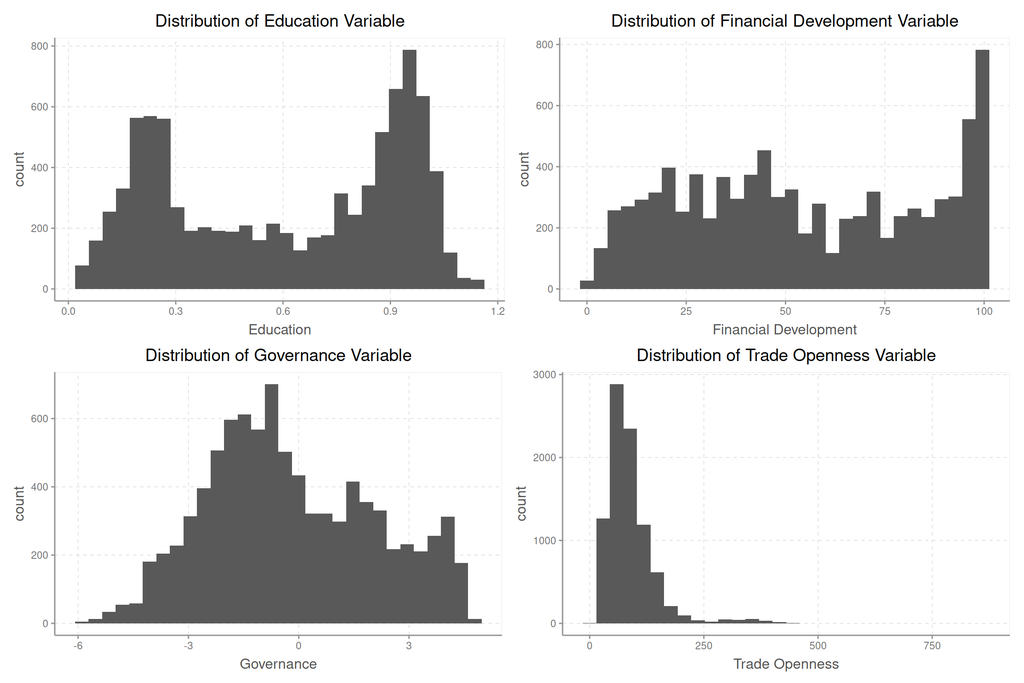

Distribution of the variables

```r
ed = my_data %>%
  ggplot(mapping = aes(x = educ)) +
  geom_histogram() +
  labs(x = 'Education',
       title = "Distribution of Education Variable")

ac = my_data %>%
  ggplot(mapping = aes(x = accounts)) +
  geom_histogram() +
  labs(x = 'Financial Development',
       title = "Distribution of Financial Development Variable")

mgov = my_data %>%
  ggplot(mapping = aes(x = governance)) +
  geom_histogram() +
  labs(x = 'Governance',
       title = "Distribution of Governance Variable")


trade = my_data %>%
  ggplot(mapping = aes(x = openess)) +
  geom_histogram() +
  labs(x = 'Trade Openness',
       title = "Distribution of Trade Openness Variable")


(ed | ac) / (mgov | trade)
```

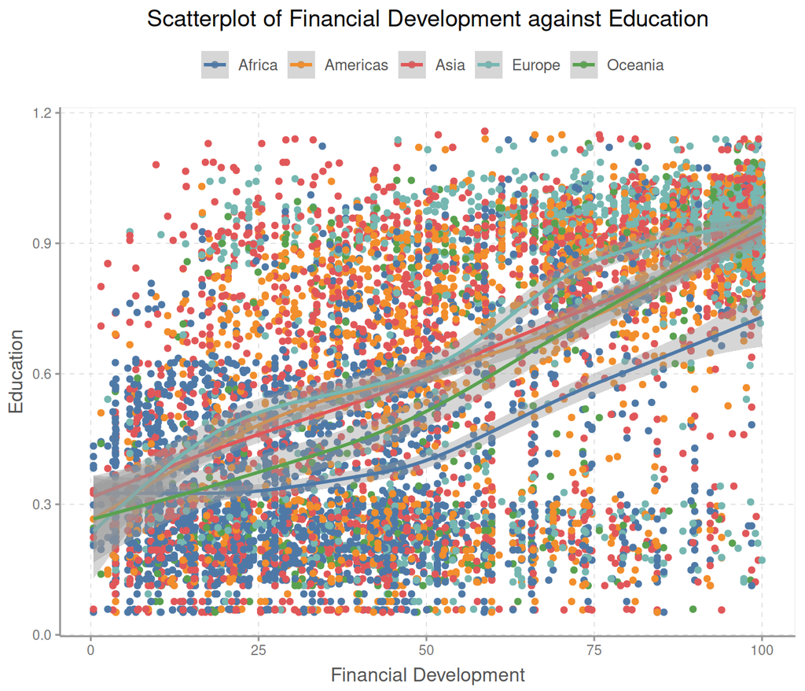

Scatterplot of Financial Development against Education

```r
my_data %>%
  ggplot(mapping = aes(x = accounts,
                       y = educ,
                       color = continent)) +
  geom_point() +
  geom_smooth() +
  scale_color_tableau() +
  labs(x = "Financial Development",
       y = "Education",
       title = "Scatterplot of Financial Development against Education") + theme(legend.title = element_blank(),
                                                                                 legend.position = "top")
```

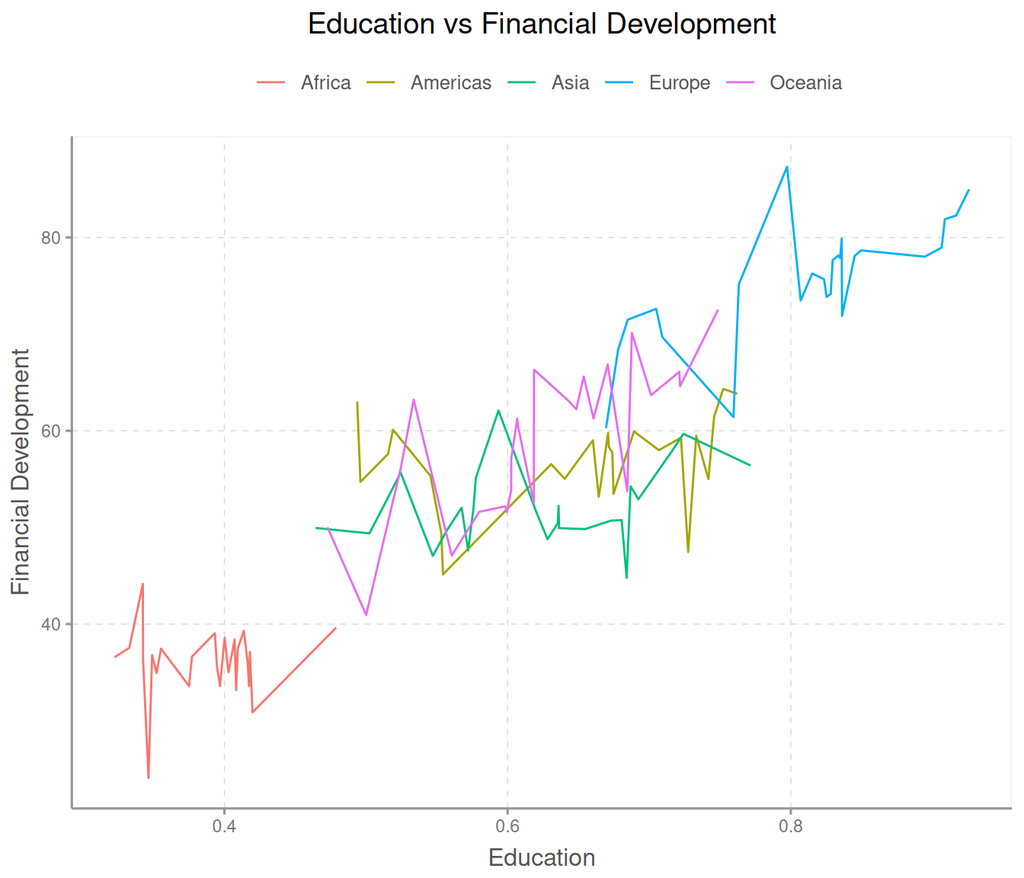

Education vs Financial Development

```r
my_data %>%
  summarise(
    accounts = mean(accounts),
    educ = mean(educ),
    .by = c(continent, time)
  ) %>%
  ggplot(aes(y = accounts,
             x = educ,
             color = continent)) +
  geom_line() +
  labs(x = "Education",
       y = "Financial Development",
       title = "Education vs Financial Development") +
  theme(
    legend.title = element_blank(),
    legend.position = "top"
  )
```

I then examine the average trends in financial development by continent over time. We see that Africa lies far below the other regions.

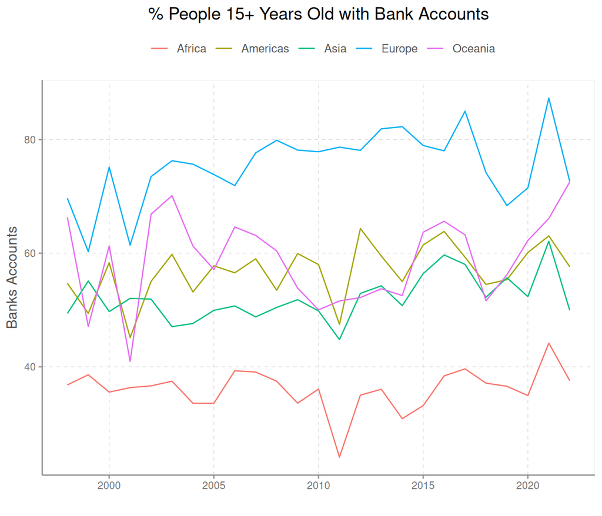

% People 15+ Years Old with Bank Accounts

```r
## Create the graphs ----
my_data %>%
  summarise(
    accounts = mean(accounts),
    .by = c(time, continent)
  ) %>%
  ggplot(mapping = aes(x = time,
                       y = accounts,
                       color = continent)) +
  geom_line(show.legend = TRUE) +
  labs(x = "", y = "Banks Accounts",
       title = "% People 15+ Years Old with Bank Accounts") +
  theme(
    legend.title = element_blank(),
    legend.position = "top"
  )
```

The figure below reinforces the low level of financial development in Africa, with Europe exhibiting the highest median financial development.

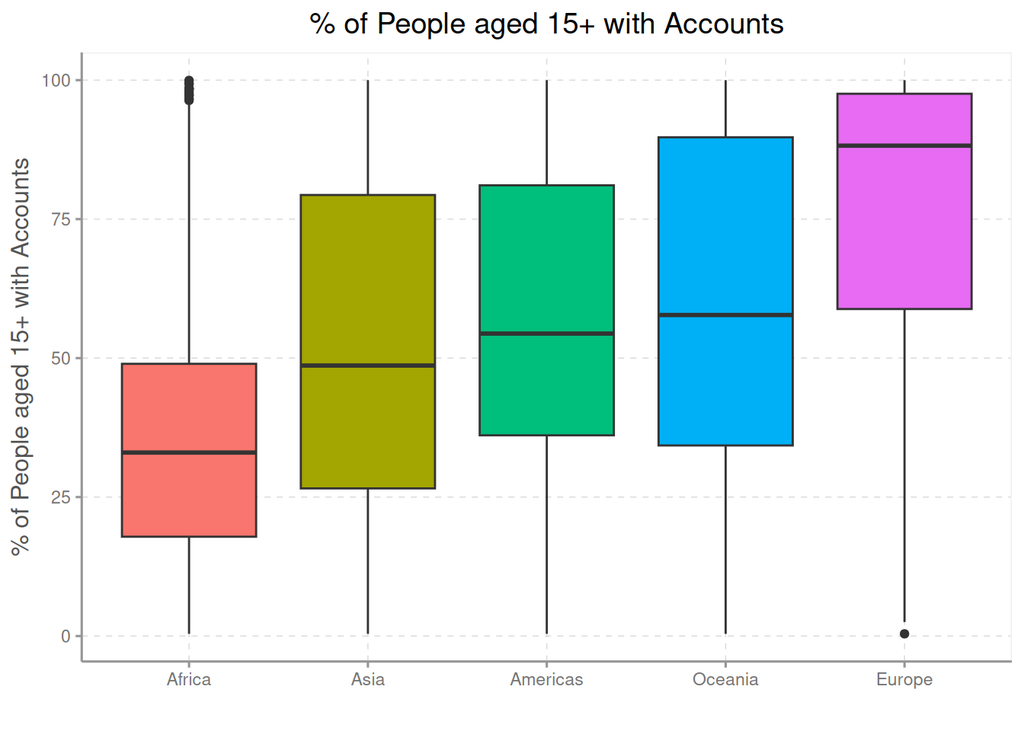

% of People aged 15+ with Accounts

```r
my_data %>%
  mutate(continent = fct_reorder(continent, accounts, median)) %>%
  ggplot(mapping = aes(y = accounts,
                       x = continent,
                       fill = continent)) +
  geom_boxplot(show.legend = FALSE) +
  labs(x = "",
       y = "% of People aged 15+ with Accounts",
       title = "% of People aged 15+ with Accounts")
```

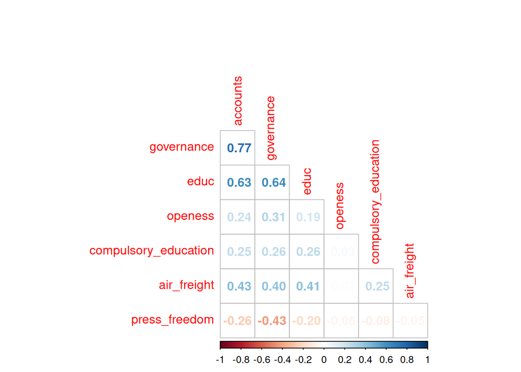

Correlation Analysis

```r
my_data %>%
  select(where(is.numeric), -time) %>%
  cor() %>%
  corrplot(
    method = "number",
    type = "lower",
    diag = FALSE
  )
```

I also summarise the data below

```r
## Summary statistics
my_data %>%
  select(where(is.numeric), -time) %>%
  skimr::skim_without_charts() %>%
  select(-n_missing, -complete_rate) %>%
  rename(
    Variable = skim_variable,
    Mean = numeric.mean,
    SD = numeric.sd,
    Min = numeric.p0,
    Q1 = numeric.p25,
    Median = numeric.p50,
    Q3 = numeric.p75,
    Max = numeric.p100
  ) %>%
  kbl(
    caption = "Summary Statistics",
    booktabs = TRUE
  ) %>%
  kable_classic(
    full_width = TRUE,
    latex_options = "hold_position"
  )
```

Summary Statistics

| skim_type | Variable | Mean | SD | Min | Q1 | Median | Q3 | Max |
| --- | --- | --- | --- | --- | --- | --- | --- | --- |
| numeric | accounts | 54.529 | 30.195 | 0.400 | 28.570 | 50.760 | 83.560 | 100.00 |
| numeric | governance | -0.198 | 2.288 | -5.910 | -1.896 | -0.576 | 1.574 | 4.78 |
| numeric | educ | 0.608 | 0.326 | 0.052 | 0.268 | 0.665 | 0.921 | 1.16 |
| numeric | openess | 89.432 | 57.769 | 2.699 | 54.632 | 77.116 | 106.332 | 863.20 |
| numeric | compulsory_education | 9.347 | 2.291 | 0.000 | 8.000 | 9.000 | 10.000 | 17.00 |
| numeric | air_freight | 13.937 | 2.432 | 0.000 | 12.515 | 14.044 | 15.454 | 20.65 |
| numeric | press_freedom | 66.228 | 45.364 | -10.000 | 28.000 | 63.440 | 90.000 | 180.00 |

# 4 **Regression Analysis**

I run panel regressions as follows;

- Fixed effects model.
- Random effects model.
- Pooled OLS

We estimate an equation of the form;

$findev_{ij} = \alpha + \beta_{1}Education_{ij} + \beta_{2}Governance_{ij} + \beta_{4}Trade_openness_{ij}$

```r
## PLM
fixed_effects <- plm(accounts ~ educ + openess + governance,
    index = c("continent", "time"),
    data = my_data,
    effect = "twoway",
    model = "within")

fixed_effects_iv <- plm(accounts ~ educ + openess + governance| compulsory_education +
                          air_freight + press_freedom,
    index = c("continent", "time"),
    data = my_data,
    effect = "twoway",
    model = "within")

pooling_effects <- plm(accounts ~ educ + openess + governance,
                      index = c("continent", "time"),
                      data = my_data,
                      effect = "twoway",
                      model = "pooling")

pooling_effects_iv <- plm(accounts ~ educ + openess + governance | compulsory_education +
                          air_freight + press_freedom,
                      index = c("continent", "time"),
                      data = my_data,
                      effect = "twoway",
                      model = "pooling")
```

The individual regression output follows.

## 4.1 The fixed effects model

### 4.1.1 Fixed effects without Instruments

Below is a summary of the fixed effects model without instruments.

```r
summary(fixed_effects)
```

```
Twoways effects Within Model

Call:
plm(formula = accounts ~ educ + openess + governance, data = my_data,
    effect = "twoway", model = "within", index = c("continent",
        "time"))

Balanced Panel: n = 5, T = 25, N = 8875

Residuals:
   Min. 1st Qu.  Median 3rd Qu.    Max.
-58.267 -12.367   0.404  11.173  82.002

Coefficients:
           Estimate Std. Error t-value            Pr(>|t|)
educ       21.76081    0.81517   26.69 <0.0000000000000002 ***
openess    -0.00196    0.00357   -0.55                0.58
governance  8.04936    0.12505   64.37 <0.0000000000000002 ***
---
Signif. codes:  0 '***' 0.001 '**' 0.01 '*' 0.05 '.' 0.1 ' ' 1

Total Sum of Squares:    6210000
Residual Sum of Squares: 2930000
R-Squared:      0.528
Adj. R-Squared: 0.526
F-statistic: 3295.38 on 3 and 8843 DF, p-value: <0.0000000000000002
```

### 4.1.2 Fixed Effects with Instruments

Then the fixed effects model WITH instruments.

```r
summary(fixed_effects_iv)
```

```
Twoways effects Within Model
Instrumental variable estimation

Call:
plm(formula = accounts ~ educ + openess + governance | compulsory_education +
    air_freight + press_freedom, data = my_data, effect = "twoway",
    model = "within", index = c("continent", "time"))

Balanced Panel: n = 5, T = 25, N = 8875

Residuals:
   Min. 1st Qu.  Median 3rd Qu.    Max.
 -76.94  -19.43   -4.49   14.62  296.60

Coefficients:
           Estimate Std. Error z-value Pr(>|z|)
educ         28.683     24.176    1.19  0.23545
openess      -0.446      0.168   -2.66  0.00786 **
governance    7.167      1.883    3.81  0.00014 ***
---
Signif. codes:  0 '***' 0.001 '**' 0.01 '*' 0.05 '.' 0.1 ' ' 1

Total Sum of Squares:    6210000
Residual Sum of Squares: 8540000
R-Squared:      0.122
Adj. R-Squared: 0.118
Chisq: 989.338 on 3 DF, p-value: <0.0000000000000002
```

## 4.2 Pooled OLS Model

### 4.2.1 Pooled OLS without Instruments

Here, I present the pooled OLS model without instruments

```r
summary(pooling_effects)
```

```
Pooling Model

Call:
plm(formula = accounts ~ educ + openess + governance, data = my_data,
    effect = "twoway", model = "pooling", index = c("continent",
        "time"))

Balanced Panel: n = 5, T = 25, N = 8875

Residuals:
   Min. 1st Qu.  Median 3rd Qu.    Max.
-59.218 -12.368   0.606  11.467  81.153

Coefficients:
            Estimate Std. Error t-value            Pr(>|t|)
(Intercept) 42.12694    0.61939   68.01 <0.0000000000000002 ***
educ        22.77823    0.78150   29.15 <0.0000000000000002 ***
openess      0.00174    0.00357    0.49                0.63
governance   8.04644    0.11469   70.16 <0.0000000000000002 ***
---
Signif. codes:  0 '***' 0.001 '**' 0.01 '*' 0.05 '.' 0.1 ' ' 1

Total Sum of Squares:    8090000
Residual Sum of Squares: 3040000
R-Squared:      0.624
Adj. R-Squared: 0.624
F-statistic: 4916.52 on 3 and 8871 DF, p-value: <0.0000000000000002
```

### 4.2.2 Pooled OLS with Instruments

Then look at the pooled OLS with instruments

```r
summary(pooling_effects_iv)
```

```
Pooling Model
Instrumental variable estimation
   (Balestra-Varadharajan-Krishnakumar's transformation)

Call:
plm(formula = accounts ~ educ + openess + governance | compulsory_education +
    air_freight + press_freedom, data = my_data, effect = "twoway",
    model = "pooling", index = c("continent", "time"))

Balanced Panel: n = 5, T = 25, N = 8875

Residuals:
   Min. 1st Qu.  Median 3rd Qu.    Max.
 -91.44  -25.70   -6.43   17.65  434.32

Coefficients:
            Estimate Std. Error z-value Pr(>|z|)
(Intercept)   76.334     39.832    1.92   0.0553 .
educ          57.623     12.494    4.61 0.000004 ***
openess       -0.621      0.370   -1.68   0.0934 .
governance     6.293      2.099    3.00   0.0027 **
---
Signif. codes:  0 '***' 0.001 '**' 0.01 '*' 0.05 '.' 0.1 ' ' 1

Total Sum of Squares:    8090000
Residual Sum of Squares: 14700000
R-Squared:      0.129
Adj. R-Squared: 0.129
Chisq: 1281.95 on 3 DF, p-value: <0.0000000000000002
```